# Final Project

Ryan Brands

4/24/2020

### Load Packages

```r
library(tidyverse)
library(nycflights13)
library(RMySQL)
library(knitr)
library(dplyr)
```

### Database Connection

```r
db = dbConnect(MySQL(),
  user = 'brandsr21',
  password = '1733802',
  dbname = 'online_retailer',
  host = 'ballenger.wlu.edu')

knitr::opts_knit$set(sql.max.print = -1)
```

### Load Data

```r
airline_data <- airlines
airport_data <- airports
flight_data <- flights
planes_data <- planes
weather_data <- weather
```

### Question 1

```r
flight_data %>%
  count(dest) %>%
  arrange(desc(n)) %>%
  rename (Count = n, Destination = dest) %>%
  head(10)
```

```
## # A tibble: 10 x 2
##    Destination Count
##    <chr>       <int>
##  1 ORD         17283
##  2 ATL         17215
##  3 LAX         16174
##  4 BOS         15508
##  5 MCO         14082
##  6 CLT         14064
##  7 SFO         13331
##  8 FLL         12055
##  9 MIA         11728
## 10 DCA          9705
```

The most common destinations, from most to least, are as follows: ORD, ATL, LAX, BOS, MCO, CLT, SFO, FLL, MIA, DCA.

Explanation: 1) I specified what dataframe I’m using, “flight_data” 2) I used a count function to count all the flights going to specific destinations 3) I used arrange and desc to make sure the list showed the highest counts first 4) I renamed my headings in my results to make them more accessible 5) I used head to limit the list to the top 10 highest counts

### Question 2

```r
flight_data %>%
  count(carrier) %>%
  arrange(desc(n)) %>%
  inner_join(airlines, by = "carrier") %>%
  rename (Carrier_Co = carrier, Count = n, Carrier_Name = name)
```

```
## # A tibble: 16 x 3
##    Carrier_Co Count Carrier_Name
##    <chr>      <int> <chr>
##  1 UA         58665 United Air Lines Inc.
##  2 B6         54635 JetBlue Airways
##  3 EV         54173 ExpressJet Airlines Inc.
##  4 DL         48110 Delta Air Lines Inc.
##  5 AA         32729 American Airlines Inc.
##  6 MQ         26397 Envoy Air
##  7 US         20536 US Airways Inc.
##  8 9E         18460 Endeavor Air Inc.
##  9 WN         12275 Southwest Airlines Co.
## 10 VX          5162 Virgin America
## 11 FL          3260 AirTran Airways Corporation
## 12 AS           714 Alaska Airlines Inc.
## 13 F9           685 Frontier Airlines Inc.
## 14 YV           601 Mesa Airlines Inc.
## 15 HA           342 Hawaiian Airlines Inc.
## 16 OO            32 SkyWest Airlines Inc.
```

Explanation: 1) I specified what dataframe I’m using, “flight_data” 2) I used a count function to count the number of flights each airline was responsible for 3) I used arrange and desc to make sure the list presented the highest counts first 4) I used an inner join to combine the flight and airlines data, so that all data from airlines would be displayed, including the carrier name 5) I renamed my headings in my results to make them more accessible

### Question 3

```r
flight_data %>%
  inner_join(airline_data, by = "carrier") %>%
  drop_na(arr_delay) %>%
  group_by(carrier, name) %>%
  summarise(mean_arr_delay = mean(arr_delay)) %>%
  arrange(desc(mean_arr_delay)) %>%
  rename (Carrier_Co = carrier, Carrier_Name = name, Mean_Arrival_Delay = mean_arr_delay)
```

```
## # A tibble: 16 x 3
## # Groups:   Carrier_Co [16]
##    Carrier_Co Carrier_Name                Mean_Arrival_Delay
##    <chr>      <chr>                                    <dbl>
##  1 F9         Frontier Airlines Inc.                  21.9
##  2 FL         AirTran Airways Corporation             20.1
##  3 EV         ExpressJet Airlines Inc.                15.8
##  4 YV         Mesa Airlines Inc.                      15.6
##  5 OO         SkyWest Airlines Inc.                   11.9
##  6 MQ         Envoy Air                               10.8
##  7 WN         Southwest Airlines Co.                   9.65
##  8 B6         JetBlue Airways                          9.46
##  9 9E         Endeavor Air Inc.                        7.38
## 10 UA         United Air Lines Inc.                    3.56
## 11 US         US Airways Inc.                          2.13
## 12 VX         Virgin America                           1.76
## 13 DL         Delta Air Lines Inc.                     1.64
## 14 AA         American Airlines Inc.                   0.364
## 15 HA         Hawaiian Airlines Inc.                  -6.92
## 16 AS         Alaska Airlines Inc.                    -9.93
```

As one can see by looking at the provided table, Frontier Airlines had the highest mean arrival day and Alaska Airlines had the lowest.

Explanation 1) I specified what dataframe I’m using, “flight_data” 2) I used an inner join to combine the flight and airlines data, so that my results included the carrier name 3) I used drop_na so that all “NA” results weren’t displayed 4) I grouped by carrier and carrier name, so that they were included in the results 5) I used summarise to create a new variable, mean_arr_delay, and then set that to equal the mean arrival delay 6) I then used arrange so that my results were listed from greatest mean arrival delay to least 7) I renamed my headings in my results to make them more accessible

### Question 4

```r
flight_data %>%
  select(dep_delay, month, day, origin) %>%
  arrange(desc(dep_delay)) %>%
  head(1) %>%
  rename(Departure_Delay = dep_delay, Month = month, Day = day, Flight_Origin = origin)
```

```
## # A tibble: 1 x 4
##   Departure_Delay Month   Day Flight_Origin
##             <dbl> <int> <int> <chr>
## 1            1301     1     9 JFK
```

Explanation 1) I specified what dataframe I’m using, “flight_data” 2) I then used select to include the requested information 3) I used arrange and desc so that the longest departure delay was listed first 4) I then used head(1) to isolate the longest departure delay as the only result 5) I renamed my headings in my results to make them more accessible

```r
weather_data %>%
  filter( month == 1, day == 9, origin == "JFK") %>%
  summarise(mean_temp = mean(temp)) %>%
  rename(Mean_Temperature = mean_temp)
```

```
## # A tibble: 1 x 1
##   Mean_Temperature
##              <dbl>
## 1             42.7
```

Explanation 1) I specified what dataframe I’m using, “weather_data” 2) I filtered my results so that a JFK flight on January 9th would be the only one in the output 3) I used summarise to create a new variable, mean_temp, and then set that to equal the mean temperature 4) I renamed my headings in my results to make them more accessible

```r
flight_data %>%
  arrange(desc(dep_delay)) %>%
  head(1) %>%
  inner_join(weather_data, by = c("month", "day", "origin")) %>%
  inner_join(airport_data, by = c("origin" = "faa")) %>%
  group_by(dep_delay, month, day, origin, name) %>%
  summarise(mean_temp = mean(temp)) %>%
  arrange(desc(dep_delay)) %>%
  head(1) %>%
  rename(Departure_Delay = dep_delay, Month = month, Day = day, Origin = origin, Airport_Name = name, Mean_Temperature = mean_temp)
```

```
## # A tibble: 1 x 6
## # Groups:   Departure_Delay, Month, Day, Origin [1]
##   Departure_Delay Month   Day Origin Airport_Name        Mean_Temperature
##             <dbl> <dbl> <int> <chr>  <chr>                          <dbl>
## 1            1301     1     9 JFK    John F Kennedy Intl             42.7
```

Explanation 1) I specified what dataframe I’m using, “flight_data” 2) I used arrange and desc so that my results would be organized by dep_delay with the longest dep_delay being on top 3) I used head 1 to isolate the longest dep_delay in my results 4) I then had to perform two joins so that all the requested information would be in my results 5) I joined “weather_data” to my code through month, day, and origin 6) I joined “airport_data” to my code through faa, which equals origin 7) Once getting all this information in my code, I had to group by again so that all said information is in my results 8) I used summarise to create the mean_temp variable, which is equal to the mean temperature 9) I then used arrange and desc again so that all the information I added through the joins was organized by dep_delay, greatest to least 10) I used head again so that the list generated by using the 2nd arrange would still only show the longest dep_delay 11) I renamed my headings in my results to make them more accessible

### Question 5

```r
flight_time_intervals <- flight_data %>%
  mutate(time = case_when(
    sched_dep_time >= 0001 & sched_dep_time <= 0600 ~ "12:01am-6am",
    sched_dep_time >= 0601 & sched_dep_time <= 1200 ~ "6:01am-12pm",
    sched_dep_time >= 1201 & sched_dep_time <= 1800 ~ "12:01pm-6pm",
    sched_dep_time >= 1801 & sched_dep_time <= 2400 ~ "6:01pm-12am"
    ))
```

Explanation 1) Here I created the new dataframe – flight_time_intervals 2) I used mutate to create a new variable, time, to represent the different time intervals 3) I split up the intervals with case_when so that there were 4 time intervals covering all 24 hours of the day (as requested)

```r
flight_time_intervals %>%
  drop_na(dep_delay) %>%
  group_by(time) %>%
  mutate(departure_delayed = ifelse(dep_delay>0,    "delayed","ontime")) %>%
  count(time, departure_delayed) %>%
  mutate(proportion_delayed = n/sum(n)) %>%
  filter(departure_delayed == "delayed") %>%
  arrange(proportion_delayed) %>%
  rename(Time_Interval = time, Departure_Delayed = departure_delayed, Count = n, Proportion_Delayed = proportion_delayed )
```

```
## # A tibble: 4 x 4
## # Groups:   Time_Interval [4]
##   Time_Interval Departure_Delayed Count Proportion_Delayed
##   <chr>         <chr>             <int>              <dbl>
## 1 12:01am-6am   delayed            1819              0.207
## 2 6:01am-12pm   delayed           32466              0.260
## 3 12:01pm-6pm   delayed           58325              0.463
## 4 6:01pm-12am   delayed           35822              0.520
```

Explanation 1) I specified what dataframe I’m using, “flight_time_intervals” 2) I used drop_na so that all “NA” results weren’t displayed 3) I then used group_by to organize my results by the time intervals 4) I then used mutate to create a new variable, departure_delayed, to specify what constitutes “delayed” and what constitutes “ontime” a. I used an ifelse statement so the program would know any dep_delay results above 0 were considered “delayed” and those not meeting that critera were “ontime” 5) I then used count to count up the number of “delayed” flights in each time interval 6) I then used mutate to create a new variable: proportion_delayed a. This was used to find the proportion of “delayed” flights in each time interval 7) I used filter so that the results only pertained to “delayed” flights 8) I used arrange to organize the time intervals, least to greatest

### Question 6

```r
flight_data %>%
  inner_join(planes, by = "tailnum") %>%
  select(air_time, dest, seats, tailnum) %>%
  arrange(desc(air_time)) %>%
  head(1) %>%
  rename(Flight_Time = air_time, Destination = dest, Seats = seats, Tail_Number = tailnum)
```

```
## # A tibble: 1 x 4
##   Flight_Time Destination Seats Tail_Number
##         <dbl> <chr>       <int> <chr>
## 1         695 HNL           292 N77066
```

Explanation 1) I specified what dataframe I’m using, “flight_data” 2) I used an inner join to include tailnum in my results 3) I used select to include the requested information 4) I used arrange and desc so that the longest air time would be first in the list 5) I used head 1 so that the longest air time was isolated in the results 6) I renamed my headings in my results to make them more accessible

### Question 7

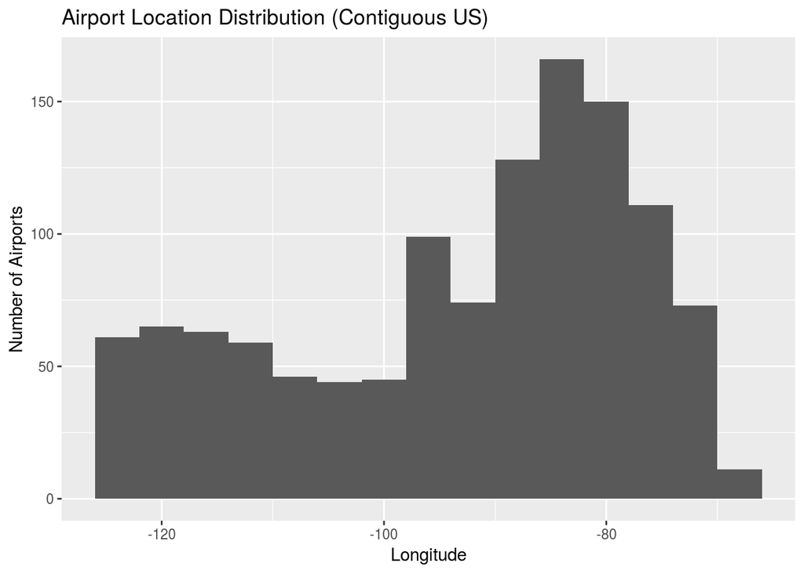

```r
airport_data %>%
  filter(
    lat > 24.520833333333332 & lat < 49.38447222222222,
         lon > -124.77169444444445 & lon < -66.94702777777778) %>%
  ggplot(aes(x = lon)) +
    geom_histogram(binwidth=4) +
    labs(title = "Airport Location Distribution (Contiguous US)", x = "Longitude", y = "Number of Airports" )
```

In terms of distribution, the data is skewed to the left. The histogram can also be described as bimodal, meaning airports are close to the east and west coasts. The most common rage appears to be approximately between -90 and -70.

Explanation 1) I specified what dataframe I’m using, “airport_data” 2) I used filter so that the results would be limited to he gepgraphic area of the contiguous United States 3) To create a histogram: a. I first used ggplot and set x=longitude as requested b. Then I used geom_histogram to create a histogram with a binwidth of 4

### Question 8

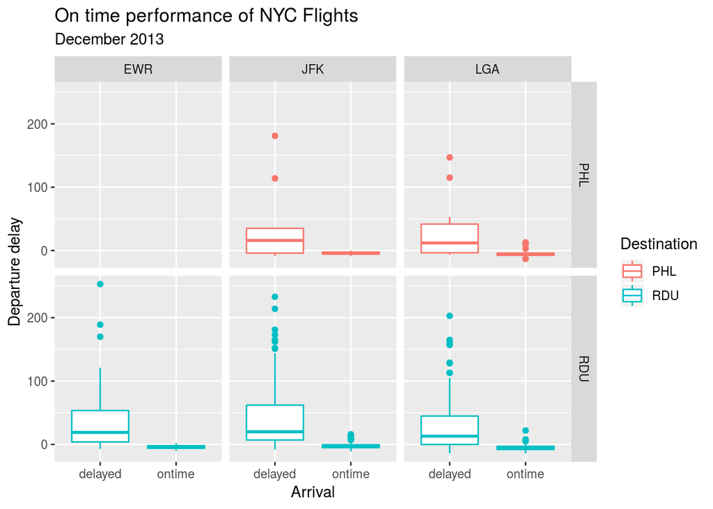

```r
flight_data %>%
  filter(month == 12, dest %in% c("PHL", "RDU")) %>%
  mutate(arrival = ifelse(arr_delay > 0, "delayed", "ontime")) %>%
  drop_na(arrival) %>%
  ggplot(aes(x = arrival, y = dep_delay, color = dest)) +
  geom_boxplot() +
  facet_grid(dest ~ origin) +
  labs(title = "On time performance of NYC Flights",
       subtitle = "December 2013",
       x = "Arrival",
       y = "Departure delay",
       color = "Destination")
```

The following display shows a few things. 1) If someone is leaving from a NY airport and going to RDU, they should expect to be delayed (and more than they would be if they were going to PHL). (2) The visual seems to suggest that EWR doesn’t fly to PHL. (3) For the airports that do fly to both destinantions (JFK and LGA), LGA customers experiecning a delay tend to wait about the same amount of time whether they are going to PHL or RDU. If they are using JFK though, it’s more likely that the delay time will be longer if they are going to RDU.

### Question 9

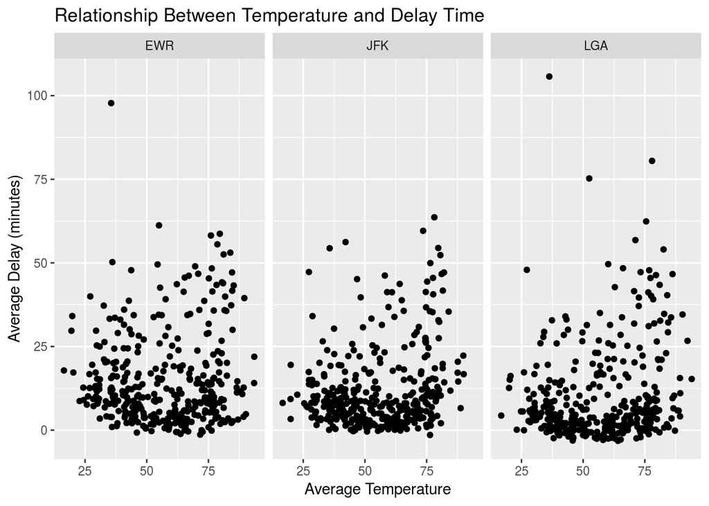

```r
flight_weather <- inner_join(flight_data, weather_data, by = c("year","month","day","origin","hour")) %>%
  group_by(month,day,origin) %>%
  summarise(average_departure_delay = mean(dep_delay, na.rm = TRUE), average_temperature = mean(temp, na.rm = TRUE))
ggplot(flight_weather, aes(x = average_temperature, y = average_departure_delay)) +
        geom_point() +
         facet_wrap(~ origin) +
           labs(title = "Relationship Between Temperature and Delay Time", x= "Average Temperature", y = "Average Delay (minutes)")
```

Explanation 1) I created a new data frame “flight_weather” by joining “flights_data” and “weather_data” through both dataframe’s like columns 2) I used group by to organize my results by month, day, and origin 3) I used summarise to create a new variable, average_departure_delay, equal to the mean of dep_delay a. I set na.rm = TRUE so that “NA” results were excluded 3) I used sumarise to create a new variable, average_temperature, equal to the mean of temp a. I set na.rm = TRUE so that “NA” results were excluded 4) I chose to create a scatter plot for my visual, I made this by: a. I used ggplot, and referenced“flight_weather” so that the program knew what dataframe my output should come from b. I set x= average_temperature, y=average_departure_delay c. I used geom_point to generate a scatter plot d. I used a facet wrap and sourced it in origin so that the output would create a scatterplot for all NY airports e. I then used labs to give my scatterplot an appropriate title and axes names

### Question 10

```sql
SELECT Country,
Count(Customer_ID) as "nbr_customers"
FROM customers
Group By(country)
ORDER BY (Count(Customer_ID)) DESC
```

37 records

| Country | nbr_customers |
| --- | --- |
| United Kingdom | 3950 |
| Germany | 95 |
| France | 87 |
| Spain | 29 |
| Belgium | 24 |
| Switzerland | 19 |
| Portugal | 19 |
| Italy | 15 |
| Finland | 12 |
| Austria | 11 |
| Norway | 10 |
| Channel Islands | 9 |
| Australia | 9 |
| Netherlands | 9 |
| Japan | 8 |
| Sweden | 8 |
| Denmark | 7 |
| Cyprus | 7 |
| Poland | 6 |
| Israel | 4 |
| USA | 4 |
| Greece | 4 |
| Unspecified | 4 |
| Canada | 4 |
| EIRE | 3 |
| Bahrain | 2 |
| Malta | 2 |
| United Arab Emirates | 2 |
| Brazil | 1 |
| RSA | 1 |
| Lithuania | 1 |
| Lebanon | 1 |
| Singapore | 1 |
| Saudi Arabia | 1 |
| Iceland | 1 |
| European Community | 1 |
| Czech Republic | 1 |

Explanation 1) First I made sure to put “sql connection = db” in the title of the chunk to connect to the sql database 2) I used select to so that country would be in my results (from the customers table) 3) I used count to count up the the # of customers 4) I used group by to group my counts by country 5) I ordered my results so that the greatest counts were on top with desc

### Question 11

```r
eu_countries <- read.csv("eucountries.csv")
```

Explnation 1) I downloaded the “eucountries.csv” into my RMD so I can use the necessary information in the later parts of this question

```r
not_uk_data <- dbSendQuery(db, 'SELECT
                                Country,
                                Customer_ID,
                                invoice_date,
                                Invoice_No as "invoice_nbr",
                                SKU,
                                description,
                                quantity,
                                actual_unit_price
                              FROM customers
                              JOIN invoices USING (Customer_ID)
                              JOIN invoice_products USING (Invoice_No)
                              JOIN products USING (SKU)
                              WHERE
                              Country != "United Kingdom"')
```

Explanation 1) To create a new dataframe, not_uk_data, I did the following: a. I used dbsendqurey to query the sql database b. I used select to choose the requested information from the database c. I used 3 joins to join all the tables together, so that all the information I queried for would be in the new dataframe d. I used where to exclude the United Kingdom from my results

```r
olr_eu_product_sales <- fetch(not_uk_data, n=-1)
```

Explanation 1) To create another new dataframe, “olr_eu_product_sales” I matched it with “not_uk_data” and used fetch so that R would recognize this action

```r
olr_eu_product_sales <- olr_eu_product_sales %>%
  mutate(invoice_date = as.Date(invoice_date)) %>%
  mutate(line_item_total = quantity * actual_unit_price) %>%
  mutate(year_month = format(invoice_date, '%Y-%m'))
```

Explanation 1)To set the requested changes to the “olr_eu_product_sales” dataframe I did the following: a. I used mutate to change the datatype invoice_date from character to date b. I used mutate to set a new column, line_item_total, that accounts for total sales amount (quantity x price) for each row in the dataframe c. I used mutate to make a new column, year_month, that reformats the invoice_date column as requested

```r
glimpse(olr_eu_product_sales)
```

```
## Observations: 44,715
## Variables: 10
## $ Country           <chr> "Iceland", "Iceland", "Iceland", "Iceland", "Icel...
## $ Customer_ID       <int> 12347, 12347, 12347, 12347, 12347, 12347, 12347, ...
## $ invoice_date      <date> 2010-12-07, 2010-12-07, 2010-12-07, 2010-12-07, ...
## $ invoice_nbr       <chr> "537626", "537626", "537626", "537626", "537626",...
## $ SKU               <chr> "20780", "20782", "21064", "21171", "21731", "221...
## $ description       <chr> "BLACK EAR MUFF HEADPHONES", "CAMOUFLAGE EAR MUFF...
## $ quantity          <dbl> 12, 6, 6, 12, 12, 12, 6, 4, 36, 12, 4, 4, 4, 4, 4...
## $ actual_unit_price <dbl> 4.65, 5.49, 5.95, 1.45, 1.65, 1.65, 2.10, 4.25, 0...
## $ line_item_total   <dbl> 55.80, 32.94, 35.70, 17.40, 19.80, 19.80, 12.60, ...
## $ year_month        <chr> "2010-12", "2010-12", "2010-12", "2010-12", "2010...
```

Explanation 1) I used glmipse to see the number of observations and variables in the dataframe, “olr_eu_product_sales”

```r
sales_by_month <- olr_eu_product_sales %>%
                    group_by(year_month) %>%
                    drop_na(year_month) %>%
                    filter(year_month != "December 2011") %>%
                    summarise(total_monthly_sales = sum(line_item_total))
```

### Question 12

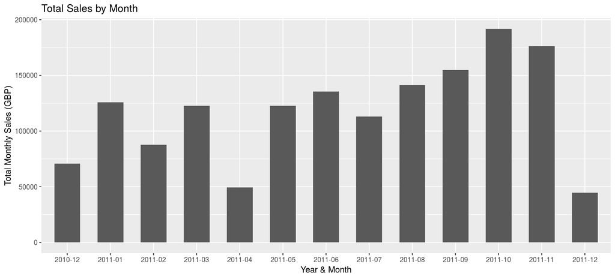

```r
sales_by_month %>%
  ggplot(aes(x = year_month, y = total_monthly_sales)) +
  geom_col(width = 0.6) +
   labs(title = "Total Sales by Month",
         x = "Year & Month",
         y = "Total Monthly Sales (GBP)")
```

Explanation 1) I specified what dataframe I’m using, “sales_by_month” 2) To make a bar chart that measured total sales by month I did the following: a. I used ggplot and set x=year_month, y=total_monthly_sales b. I used geom_col to make a bar chart with bars of width 0.6 c. I set the bar chart title and its x and y axes with the appropriate headings as requested *d. To properly spread out the x axis itself, I used fig.width in the chunk title

### Error Log

I used this link to find out how to exclude “NA” results with drop_na https://tidyr.tidyverse.org/reference/drop_na.html (Date: 4/20)

I used these links to learn more about geom_col and to increase the width of my bar chart on question 12 https://stagraph.com/HowTo/Plot/Geometries/Geom/col https://bookdown.org/yihui/rmarkdown/tufte-figures.html (Date: 4/23)

### Honor Pledge

On my honor, I have neither given nor received any unacknowledged aid on this project. - Ryan Brands